# Assignment CNN

## Convolutional Neural Networks for Tree Bark Classification

For this week's exercise you will build a model for tree bark classification. The data set we will use is this one here: https://www.vicos.si/Downloads/TRUNK12 (just above 1GB)

One way to solve this task is to use the features computed by different layers of a standard convolutional neural network, feel free to pick one here: https://keras.io/api/applications/ That page also contains the code examples for extracting features from different network layers and finetuning models.

You don't need to fine tune models though - given the small data set size it's a perfectly reasonable approach to just extract activations for all images and use a simple model like KNN or logistic regression (which would essentially amount to fine tuning).

If you have time and/or a GPU, you could try various layers of VGG (https://keras.io/api/applications/vgg/#vgg16-function). If you don't you could experiment with smaller/faster CNNs as NASNET (https://keras.io/api/applications/nasnet/#nasnetmobile-function) or MobileNet (https://keras.io/api/applications/mobilenet/#mobilenetv2-function).

The goal of this task is that you explore how the most important feature of tree/bark recognition can be predicted with the features in earlier or later layers of a CNN.

There will be no guidance with a pre-implemented notebook for data preprocessing, but we're happy to answer questions.

Please submit your final notebook (without the data set). The notebook should show how your model is performing on a test split of 20% for at least an early layer and one of the last layers of a CNN.

```python
import math
import pathlib

import numpy as np
import matplotlib.pyplot as plt
import tensorflow as tf

from sklearn.metrics import confusion_matrix

from tensorflow.data.experimental import cardinality

from tensorflow.keras import Input
from tensorflow.keras import preprocessing
from tensorflow.keras import models
from tensorflow.keras import layers
from tensorflow.keras import optimizers
from tensorflow.keras import applications
from tensorflow.keras.losses import SparseCategoricalCrossentropy
from tensorflow.keras.applications import MobileNetV2
```

## Loading the data

```python
data_url = "https://www.vicos.si/Downloads/TRUNK12"
data_dir = tf.keras.utils.get_file('/Users/Vy/Documents/TRUNK12', origin=data_url, untar=True)
data_dir = pathlib.Path(data_dir)
```

```python
# Total number of images
image_count = len(list(data_dir.glob('*/*.JPG')))
print(image_count)
```

```
393
```

```python
# Set default parameters
batch_size = 32
img_height = img_width = 224       # Because MobileNet expects a certain image size as input
learning_rate = 0.001
input_shape = (img_width, img_height, 3)
```

## Splitting the data

Split images into train and validation data (60%, 40%):

```python
def split_data(subset, data_dir=data_dir, validation_split=0.4, batch_size=batch_size, img_height=img_height, img_width=img_width):
    ds = preprocessing.image_dataset_from_directory(
      data_dir,
      validation_split=validation_split,
      subset=subset,
      labels='inferred',
      label_mode='int',
      color_mode='rgb',
      seed=13353,
      image_size=(img_height, img_width),
      batch_size=batch_size)
    return ds

train_ds = split_data("training")
val_ds = split_data("validation")
```

```
Found 393 files belonging to 12 classes.
Using 236 files for training.
Found 393 files belonging to 12 classes.
Using 157 files for validation.
```

Set ~half of the batches of the validation data aside as test data, so the ratio will approx. be: 60% training, 20% validation and 20% test data

```python
val_batches = cardinality(val_ds)          # returns the cardinality of the validation data set (number of batches)
test_ds = val_ds.take(math.ceil(val_batches / 2))
val_ds = val_ds.skip(math.ceil(val_batches / 2))
```

```python
print('Number of training batches: %d' % cardinality(train_ds))
print('Number of validation batches: %d' % cardinality(val_ds))
print('Number of test batches: %d' % cardinality(test_ds))
```

```
Number of training batches: 8
Number of validation batches: 2
Number of test batches: 3
```

```python
# Get the number of classes
class_names = train_ds.class_names
num_classes = len(class_names)
```

### Examine/Visualize some of the data

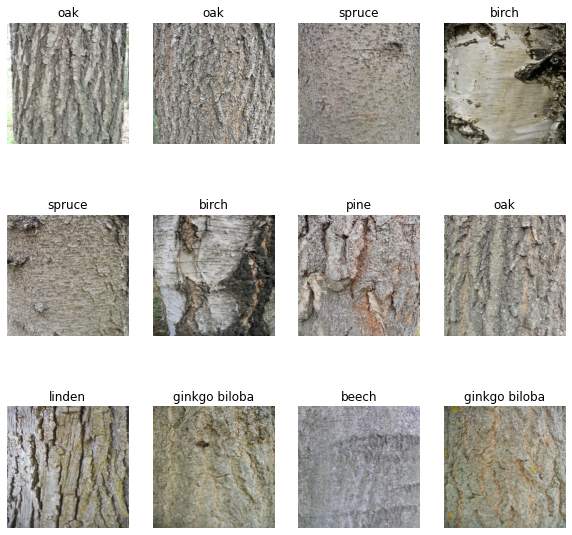

```python
plt.figure(figsize=(10, 10))
for images, labels in train_ds.take(1):
    for i in range(12):
        ax = plt.subplot(3, 4, i + 1)
        plt.imshow(images[i].numpy().astype("uint8"))
        plt.title(class_names[labels[i]])
        plt.axis("off")
```

## Building the model

### Use MobileNet V2 model as pre-trained model

Without the classifier part, so include_top is set to false. We will also use some of the later layers of the model.

```python
base_model = MobileNetV2(input_shape=input_shape, weights='imagenet', include_top=False)
```

```python
base_model = models.Model(inputs=base_model.input, outputs=base_model.layers[-12].output)
```

### Rescale pixel values

Each Keras Application expects a specific kind of input preprocessing. For MobileNet, we call tf.keras.applications.mobilenet.preprocess_input on our inputs before passing them to the model. mobilenet.preprocess_input will scale input pixels between -1 and 1.

```python
preprocess_input = applications.mobilenet_v2.preprocess_input
```

### Adding new classifier layers

We're using the pre-trained model as a feature extraction component. We then want to train the new layers of the model without updating the weights of the MobileNetV2 layers (setting the trainable attribute to false). This allows the new output layers to learn to interpret the learned features of the base model.

```python
# Feature extraction example

images, labels = next(iter(train_ds))
features = base_model.predict(images)
print(images.shape)
print(features.shape)
```

```
(32, 224, 224, 3)
(32, 7, 7, 160)
```

```python
# Freeze the convolutional base
base_model.trainable = False

# Average pooling layer: Converts the 224x224x3 image into a 7x7x160 block of features
average_pooling_layer = layers.GlobalAveragePooling2D()

# Fully-connected layer
fc_layer = layers.Dense(128, activation='relu')

# Output layer
prediction_layer = layers.Dense(num_classes, activation='softmax')
```

```python
# Put everything together
inputs = Input(shape=input_shape)
x = preprocess_input(inputs)
x = base_model(x, training = False)
x = average_pooling_layer(x)
x = fc_layer(x)
x = layers.Dropout(0.2)(x)
outputs = prediction_layer(x)
model = tf.keras.Model(inputs, outputs)
```

```python
model.summary()
```

```
Model: "model_8"
_________________________________________________________________
Layer (type)                 Output Shape              Param #
=================================================================
input_7 (InputLayer)         [(None, 224, 224, 3)]     0
_________________________________________________________________
tf.math.truediv_2 (TFOpLambd (None, 224, 224, 3)       0
_________________________________________________________________
tf.math.subtract_2 (TFOpLamb (None, 224, 224, 3)       0
_________________________________________________________________
model_7 (Functional)         (None, 7, 7, 160)         1364864
_________________________________________________________________
global_average_pooling2d_2 ( (None, 160)               0
_________________________________________________________________
dense_3 (Dense)              (None, 128)               20608
_________________________________________________________________
dropout_2 (Dropout)          (None, 128)               0
_________________________________________________________________
dense_4 (Dense)              (None, 12)                1548
=================================================================
Total params: 1,387,020
Trainable params: 22,156
Non-trainable params: 1,364,864
_________________________________________________________________
```

## Compile the model

We're using the Adam optimizer with a learning rate of 0.001 (see default parameters above). The Sparse Categorical Cross Entropy loss is used.

```python
model.compile(optimizer=optimizers.Adam(learning_rate=learning_rate),
        loss=SparseCategoricalCrossentropy(from_logits=True),
        metrics=['sparse_categorical_accuracy'])
```

## Train the model

We'll train for 15 epochs.

```python
history = model.fit(train_ds, validation_data=val_ds, validation_steps=len(val_ds), epochs=15)
```

## Plot the learning curves

Here we see the learning curves of the training and validation accuracy/loss when using the MobileNet V2 base model as a fixed feature extractor. (Code for plotting taken from https://www.tensorflow.org/tutorials/images/transfer_learning#learning_curves)

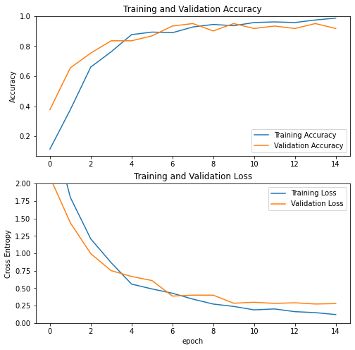

```python
acc = history.history['sparse_categorical_accuracy']
val_acc = history.history['val_sparse_categorical_accuracy']

loss = history.history['loss']
val_loss = history.history['val_loss']

plt.figure(figsize=(8, 8))
plt.subplot(2, 1, 1)
plt.plot(acc, label='Training Accuracy')
plt.plot(val_acc, label='Validation Accuracy')
plt.legend(loc='lower right')
plt.ylabel('Accuracy')
plt.ylim([min(plt.ylim()),1])
plt.title('Training and Validation Accuracy')

plt.subplot(2, 1, 2)
plt.plot(loss, label='Training Loss')
plt.plot(val_loss, label='Validation Loss')
plt.legend(loc='upper right')
plt.ylabel('Cross Entropy')
plt.ylim([0,2.0])
plt.title('Training and Validation Loss')
plt.xlabel('epoch')
plt.show()
```

## Evaluation

We will evaluate the model using the test data. The test accuracy is approx. 95.8%.

```python
test_loss, test_acc = model.evaluate(test_ds)
print('Test accuracy: ', test_acc)
```

```
Test accuracy:  0.9583333134651184
```

### Predicting the tree species using the new model

We will use a batch from the test dataset, get the predicted labels and compare with the true labels. Both are printed out below for comparison, together with the confusion matrix for that batch. For visualization the images are plotted as well.

```python
image_batch, label_batch = test_ds.as_numpy_iterator().next()
```

```python
predictions = model.predict_on_batch(image_batch)
scores = tf.nn.softmax(predictions)
pred = np.empty((32,), dtype='int32')
for index, score in enumerate(scores):
    pred[index] = np.argmax(score)
```

```python
print('Predictions:\n', pred)
print('Labels:\n', label_batch)
confusion_matrix(label_batch, pred, labels = range(0,12))
```

```
Predictions:
 [ 6  2  7  0  2  5  2  4  9  0  6  5  6  3  6  5  5  5 11 11  0  0  4  3
  5  5  6  6 11  8 11  8]
Labels:
 [ 6  2  7  0  2  5  2  4  9  0  6  5  6  3  6  5  5  5 11 11  0  0  4  3
  5  1  6  6 11  8 11  8]
```

```
array([[4, 0, 0, 0, 0, 0, 0, 0, 0, 0, 0, 0],
       [0, 0, 0, 0, 0, 1, 0, 0, 0, 0, 0, 0],
       [0, 0, 3, 0, 0, 0, 0, 0, 0, 0, 0, 0],
       [0, 0, 0, 2, 0, 0, 0, 0, 0, 0, 0, 0],
       [0, 0, 0, 0, 2, 0, 0, 0, 0, 0, 0, 0],
       [0, 0, 0, 0, 0, 6, 0, 0, 0, 0, 0, 0],
       [0, 0, 0, 0, 0, 0, 6, 0, 0, 0, 0, 0],
       [0, 0, 0, 0, 0, 0, 0, 1, 0, 0, 0, 0],
       [0, 0, 0, 0, 0, 0, 0, 0, 2, 0, 0, 0],
       [0, 0, 0, 0, 0, 0, 0, 0, 0, 1, 0, 0],
       [0, 0, 0, 0, 0, 0, 0, 0, 0, 0, 0, 0],
       [0, 0, 0, 0, 0, 0, 0, 0, 0, 0, 0, 4]])
```

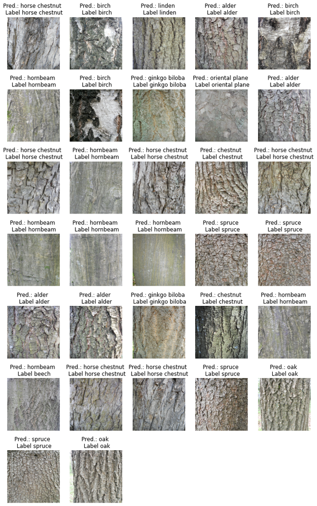

```python
# Batch images visualized with their predicted and true label
plt.figure(figsize=(12, 20))
for i in range(32):
    ax = plt.subplot(7, 5, i + 1)
    plt.imshow(image_batch[i].astype("uint8"))
    plt.title("Pred.: {} \n Label {}".format(class_names[pred[i]], class_names[label_batch[i]]))
    plt.axis("off")
```

## Using earlier layers of the CNN

```python
new_base_model = models.Model(inputs=base_model.input, outputs=base_model.layers[17].output)
```

```python
new_base_model.summary()
```

```
Model: "model_9"
_________________________________________________________________
Layer (type)                 Output Shape              Param #
=================================================================
input_6 (InputLayer)         [(None, 224, 224, 3)]     0
_________________________________________________________________
Conv1 (Conv2D)               (None, 112, 112, 32)      864
_________________________________________________________________
bn_Conv1 (BatchNormalization (None, 112, 112, 32)      128
_________________________________________________________________
Conv1_relu (ReLU)            (None, 112, 112, 32)      0
_________________________________________________________________
expanded_conv_depthwise (Dep (None, 112, 112, 32)      288
_________________________________________________________________
expanded_conv_depthwise_BN ( (None, 112, 112, 32)      128
_________________________________________________________________
expanded_conv_depthwise_relu (None, 112, 112, 32)      0
_________________________________________________________________
expanded_conv_project (Conv2 (None, 112, 112, 16)      512
_________________________________________________________________
expanded_conv_project_BN (Ba (None, 112, 112, 16)      64
_________________________________________________________________
block_1_expand (Conv2D)      (None, 112, 112, 96)      1536
_________________________________________________________________
block_1_expand_BN (BatchNorm (None, 112, 112, 96)      384
_________________________________________________________________
block_1_expand_relu (ReLU)   (None, 112, 112, 96)      0
_________________________________________________________________
block_1_pad (ZeroPadding2D)  (None, 113, 113, 96)      0
_________________________________________________________________
block_1_depthwise (Depthwise (None, 56, 56, 96)        864
_________________________________________________________________
block_1_depthwise_BN (BatchN (None, 56, 56, 96)        384
_________________________________________________________________
block_1_depthwise_relu (ReLU (None, 56, 56, 96)        0
_________________________________________________________________
block_1_project (Conv2D)     (None, 56, 56, 24)        2304
_________________________________________________________________
block_1_project_BN (BatchNor (None, 56, 56, 24)        96
=================================================================
Total params: 7,552
Trainable params: 0
Non-trainable params: 7,552
_________________________________________________________________
```

```python
# Again, put everything together (same as above), but use the new base model
inputs = Input(shape=input_shape)
x = preprocess_input(inputs)
x = new_base_model(x, training = False)
x = layers.GlobalAveragePooling2D()(x)
x = layers.Dense(128, activation='relu')(x)
x = layers.Dropout(0.2)(x)
outputs = layers.Dense(num_classes, activation='softmax')(x)
new_model = tf.keras.Model(inputs, outputs)
```

```python
new_model.summary()
```

```
Model: "model_10"
_________________________________________________________________
Layer (type)                 Output Shape              Param #
=================================================================
input_8 (InputLayer)         [(None, 224, 224, 3)]     0
_________________________________________________________________
tf.math.truediv_3 (TFOpLambd (None, 224, 224, 3)       0
_________________________________________________________________
tf.math.subtract_3 (TFOpLamb (None, 224, 224, 3)       0
_________________________________________________________________
model_9 (Functional)         (None, 56, 56, 24)        7552
_________________________________________________________________
global_average_pooling2d_3 ( (None, 24)                0
_________________________________________________________________
dense_5 (Dense)              (None, 128)               3200
_________________________________________________________________
dropout_3 (Dropout)          (None, 128)               0
_________________________________________________________________
dense_6 (Dense)              (None, 12)                1548
=================================================================
Total params: 12,300
Trainable params: 4,748
Non-trainable params: 7,552
_________________________________________________________________
```

```python
# Compile the new model
new_model.compile(optimizer=optimizers.Adam(learning_rate=learning_rate),
        loss=SparseCategoricalCrossentropy(from_logits=True),
        metrics=['sparse_categorical_accuracy'])
```

```python
# Train the new model (15 epochs, same as above)
history = new_model.fit(train_ds, validation_data=val_ds, validation_steps=len(val_ds), epochs=15)
```

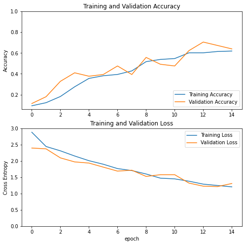

```python
# Plot the accuracy and loss using the new model
acc = history.history['sparse_categorical_accuracy']
val_acc = history.history['val_sparse_categorical_accuracy']

loss = history.history['loss']
val_loss = history.history['val_loss']

plt.figure(figsize=(8, 8))
plt.subplot(2, 1, 1)
plt.plot(acc, label='Training Accuracy')
plt.plot(val_acc, label='Validation Accuracy')
plt.legend(loc='lower right')
plt.ylabel('Accuracy')
plt.ylim([min(plt.ylim()),1])
plt.title('Training and Validation Accuracy')

plt.subplot(2, 1, 2)
plt.plot(loss, label='Training Loss')
plt.plot(val_loss, label='Validation Loss')
plt.legend(loc='upper right')
plt.ylabel('Cross Entropy')
plt.ylim([0,3.0])
plt.title('Training and Validation Loss')
plt.xlabel('epoch')
plt.show()
```

### Test accuracy with the new model

The test accuracy using the model with the earlier layers of the pre-trained model is not as good as that of the one using a later layer of the base model. The accuracy here is approx. 63.5%, which is significantly lower.

```python
test_loss, test_acc = new_model.evaluate(test_ds)
print('Test accuracy: ', test_acc)
```

```
Test accuracy:  0.6354166865348816
```